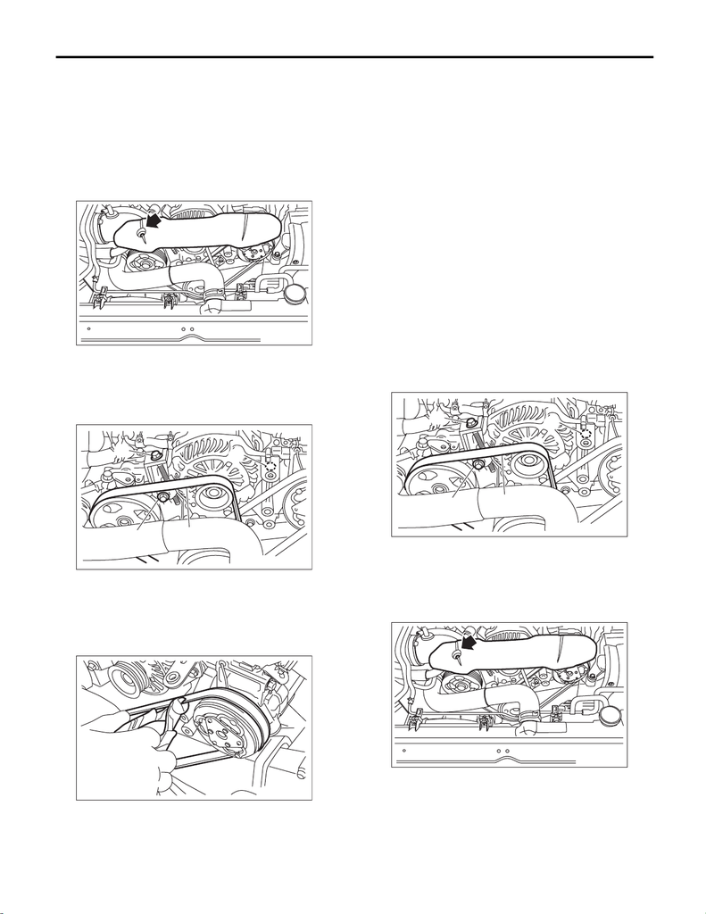

ME(STI)-41

V-belt

MECHANICAL

12.V-belt

A: REMOVAL

NOTE:

When replacing a single part, perform the work with

the engine assembly installed to body.

1. FRONT SIDE BELT

1) Remove the V-belt covers.

2) Remove the air intake duct. <Ref. to IN(STI)-11,

REMOVAL, Air Intake Duct.>

3) Loosen the bolt (A).

4) Loosen the slider bolt (B).

5) Remove the front side belt (C).

2. REAR SIDE BELT

1) Remove the front side belts. <Ref. to ME(STI)-

41, FRONT SIDE BELT, REMOVAL, V-belt.>

2) Cut the rear side belt with a wire cutter, etc., and

discard.

B: INSTALLATION

1. FRONT SIDE BELT

CAUTION:

• When reusing the front side belt, wipe off

dust and water with cloth.

• Do not use the front side belt if there is any

oil, grease or coolant on the belt.

• Be careful not to rub the belt end surface with

bare hands; exposed core may cause injury.

1) Wipe off any dust, oil and water on the groove of

each pulley with cloth.

2) Install the front side belt (C), and adjust the slider

bolt (B) so as to obtain the specified belt tension.

<Ref. to ME(STI)-47, INSPECTION, V-belt.>

3) Tighten the bolt (A).

4) Tighten the slider bolt (B).

Tightening torque:

Bolt (A)

25 N·m (2.5 kgf-m, 18.4 ft-lb)

Slider bolt (B)

8 N·m (0.8 kgf-m, 5.9 ft-lb)

5) Install the air intake duct. <Ref. to IN(STI)-11, IN-

STALLATION, Air Intake Duct.>

6) Install the V-belt cover.

Tightening torque:

13 N·m (1.3 kgf-m, 9.6 ft-lb)

FU-03487

ME-04947

(A)

(A)

(A)

(C)

(B)

(A)

ME-03343

ME-04947

(A)

(A)

(A)

(C)

(B)

(A)

FU-03487

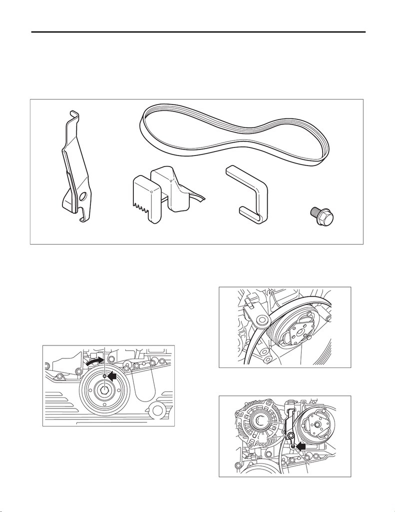

ME(STI)-42

V-belt

MECHANICAL

2. REAR SIDE BELT

CAUTION:

• Do not re-use the rear side belt.

• Be careful not to let oil, grease or coolant contact a new rear side belt.

• Be careful not to rub the belt end surface with bare hands; exposed core may cause injury.

• To install the rear side belt, always use the provided tools (belt stopper, belt guide, belt guide hold-

er, and bolt).

1) Wipe off any dust, oil and water on the groove of

each pulley with cloth.

2) Wipe off any oil, water, dirt, and rust on the front

of the crank pulley with cloth.

3) Slowly turn the crank pulley clockwise so that the

service hole of the crank pulley comes around the

top.

CAUTION:

Do not turn the crank pulley counterclockwise.

4) Hook a new rear side belt on the A/C compres-

sor pulley.

5) As shown in the figure, insert the claw of the belt

stopper (A) to the lower hole (B) of the compressor

bracket, then attach with bolt (C).

(A) Rear side belt (C) Belt guide (E) Bolt

(B) Belt stopper (D) Belt guide holder

ME-04287

(A)

(B)

(C)

(D)

(E)

ME-03500

ME-03501

ME-04670

(A)

(C)

(B)

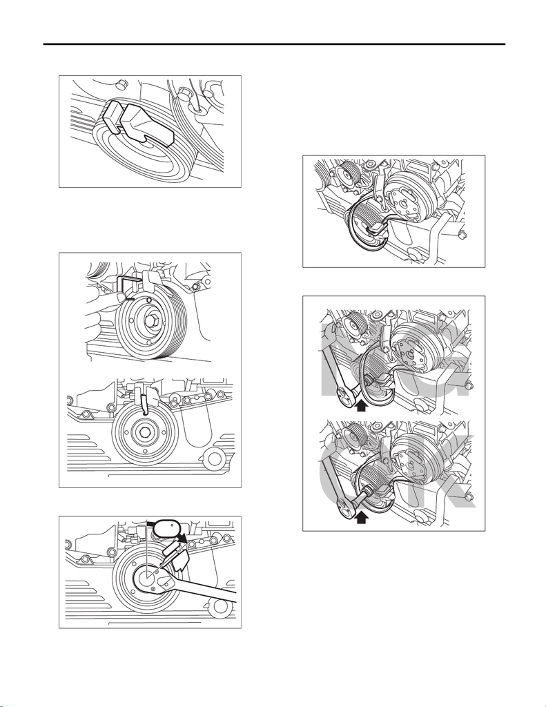

ME(STI)-43

V-belt

MECHANICAL

6) Place the belt guide while aligning it with the belt

line of the crank pulley on the front side belt side.

7) Insert the belt guide holder into the service hole

of the crank pulley so that the belt guide comes in

between.

NOTE:

Place the belt guide holder with the longer side up.

8) Slowly turn the crank pulley clockwise until the

belt guide comes to approximately 45°.

9) Place the rib surface of the rear side belt into the

crank pulley groove, so that the rear side belt

comes in between the belt guide holder.

CAUTION:

When it is difficult to place the rear side belt to

the crank pulley groove, pull out the belt guide

holder half way, then place the rear side belt

into the groove so that it comes in between the

belt guide holder.

10) Place the tool through the loop of the rear side

belt, and set on the crank pulley bolt.

ME-04289

ME-03504

ME-03505

45

ME-04671

ME-04672

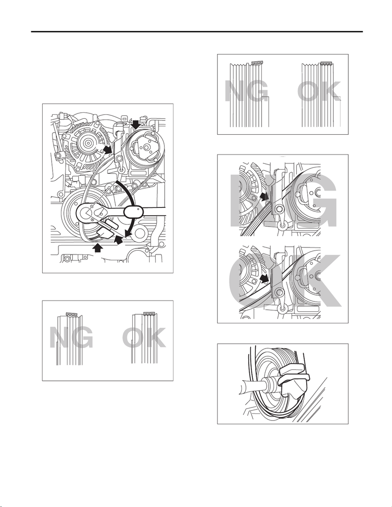

ME(STI)-44

V-belt

MECHANICAL

11) While checking the following, slowly turn the

crank pulley approximately 90° clockwise so that

the belt guide comes to the position shown in the

figure.

CAUTION:

When turning the crank pulley, always make

sure that the belt guide is not off from the crank

pulley groove.

(1) The rib of the rear side belt is securely

placed on the groove of the A/C compressor

pulley.

(2) The rib of the rear side belt is securely

placed on the groove of the crank pulley.

(3) The surface of the rear side belt is held by

the belt stopper.

(4) The rear side belt is securely placed on the

belt guide.

ME-04656

(4)

(2)

(3)

(1)

90

ME-04678

ME-04679

ME-04673

ME-04139

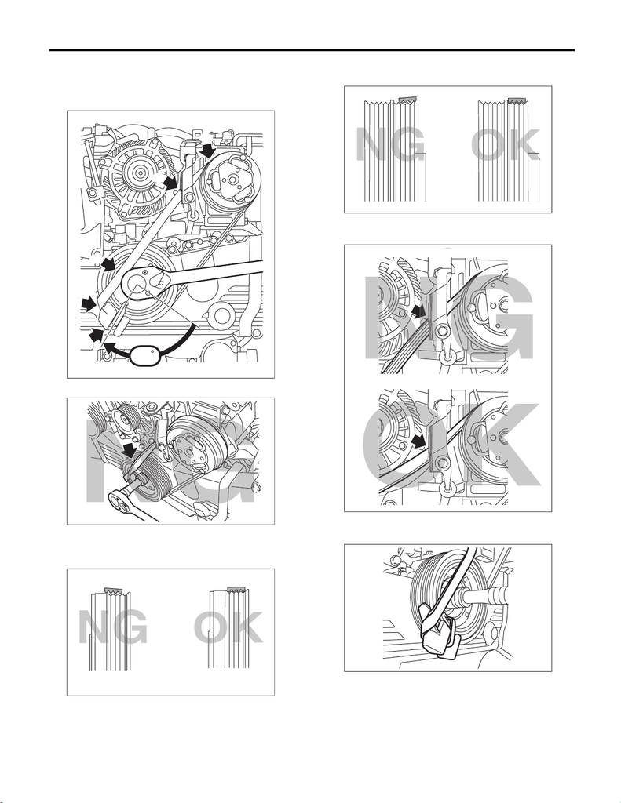

ME(STI)-45

V-belt

MECHANICAL

12) While checking the following, slowly turn the

crank pulley approximately 90° clockwise so that

the belt guide comes to the position shown in the

figure.

(1) The rear side belt is not twisted.

(2) The rib of the rear side belt is securely

placed on the groove of the A/C compressor

pulley.

(3) The rib of the rear side belt is securely

placed on the groove of the crank pulley.

(4) The surface of the rear side belt is held by

the belt stopper.

(5) The rear side belt is securely placed on the

belt guide.

ME-04657

(2)

(4)

(1)

(5)

(3)

90

ME-04674

ME-04678

ME-04679

ME-04673

ME-03530

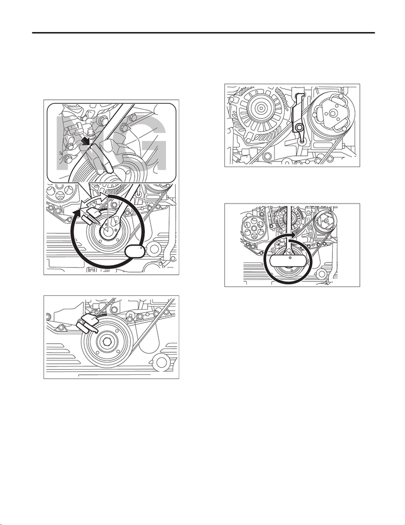

ME(STI)-46

V-belt

MECHANICAL

13) Slowly turn the crank pulley clockwise, and in-

stall the rear side belt.

CAUTION:

Be careful that the total of procedures 8), 11),

12) and 13) does not exceed 330°; failure to do

so may cause damage to the rear side belt and

fall of the belt guide holder.

14) Remove the belt guide and belt guide holder

from the crank pulley.

15) Remove the belt stopper from the compressor

bracket.

CAUTION:

Always remove the belt stopper; failure to do so

may cause smoke, fire, or belt cutting.

16) Make sure that the belt rib is securely installed

on the groove of each pulley, then turn the crank

pulley slowly, twice in the clockwise direction, to

seat the rear side belt properly.

17) Discard the provided tools (belt stopper, belt

guide, belt guide holder, and bolt) that are used.

18) Install the front side belt. <Ref. to ME(STI)-41,

FRONT SIDE BELT, INSTALLATION, V-belt.>

330

ME-03510

ME-03526

ME-04675

ME-03511

360 x2

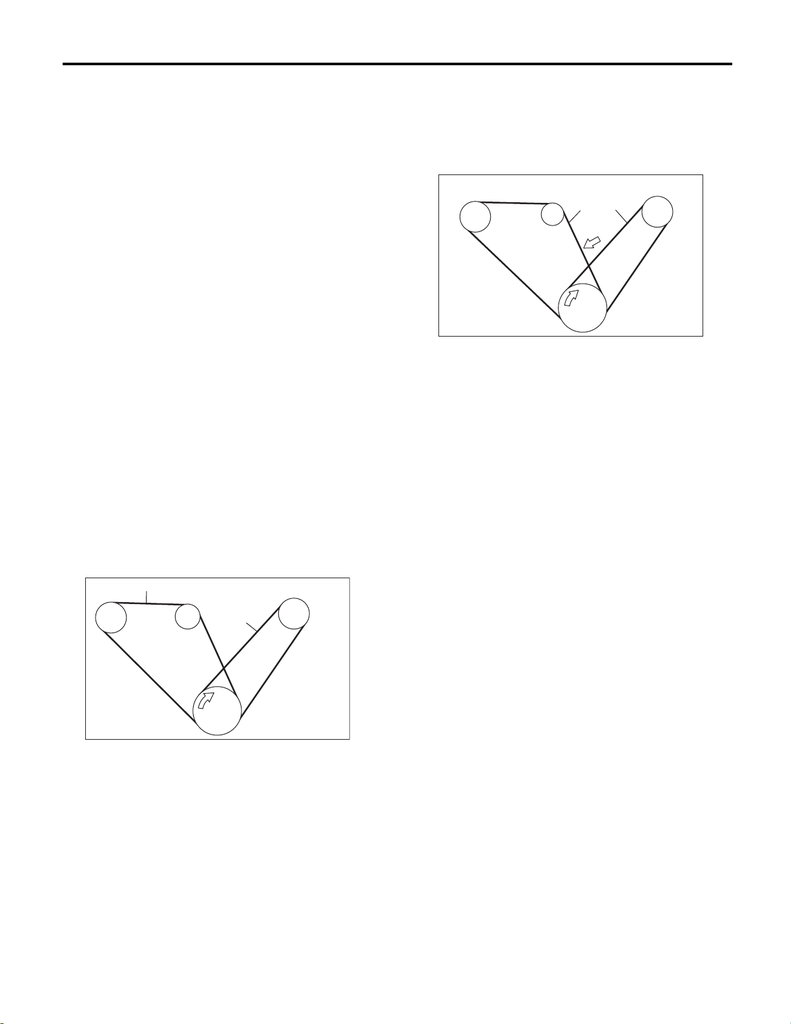

ME(STI)-47

V-belt

MECHANICAL

C: INSPECTION

1. FRONT SIDE BELT

CAUTION:

Check and adjust the front side belt tension so

that it is within the specified range. Using the

belt with a tension out of the specified range

may result in a fault such as the following:

• If the front side belt tension is higher, unex-

pected force is generated at the power steering

oil pump, generator and crankshaft bearing,

causing abnormal noise due to abnormal wear

of the bearing.

• If the front side belt tension is lower, the front

side belt and crank pulley slip, causing abnor-

mally high temperature on the crank pulley due

to frictional heat. If this condition repeatedly

occurs, the front side belt may abnormally

wear, causing abnormal noise, front side belt

damage or crank pulley damage.

1) Replace the front side belt, if crack, fraying or

wear is found.

2) Check the front side belt tension and adjust it if

necessary by changing the generator installing po-

sition.

Front side belt tension (with belt tension

gauge):

When installing new parts

640 — 780 N (65 — 80 kgf, 144 — 175 lbf)

At inspection

490 — 640 N (50 — 65 kgf, 110 — 144 lbf)

Front side belt tension (without belt tension

gauge):

When installing new parts

7 — 9 mm (0.276 — 0.354 in)

At inspection

9 — 11 mm (0.354 — 0.433 in)

3) Start the engine and confirm that the V-belt ro-

tates smoothly and no abnormal noise is emitted.

2. REAR SIDE BELT

Replace the rear side belt, if crack, fraying or wear

is found, or noise is emitted.

NOTE:

For the rear side belt, a stretch type belt is used,

and therefore, it is not necessary to check deflec-

tion nor tension.

(A) Front side belt

(B) Rear side belt

C/P Crank pulley

GEN Generator pulley

P/S Power steering oil pump pulley

A/C A/C compressor pulley

ME-03313

C/P

P/S

A/C

GEN

(A)

(B)

(A) Front side belt

(B) Rear side belt

(C) 98 N (10 kgf, 22 lbf)

C/P Crank pulley

GEN Generator pulley

P/S Power steering oil pump pulley

A/C A/C compressor pulley

ME-03314

(A)

(B)

GEN

C/P

A/C

P/S

(C)